# Collatz

Jorge Vila Tomás

2021-09-24

# 1 Secuencia de Collatz

```r
N <- 5
# Introducimos el primer número de la secuencia en la lista de resultados
result <- c(N)
while (N!=1){
  # Comprobamos si es par con la operacion módulo
  if (N%%2==0){
    N <- N/2
  } else{
    N <- N*3+1
  }
  # Añadimos el nuevo valor de N a la secuencia
  result <- c(result, N)
}
NSec <- length(result)
cat('La longitud de la secuencia generada es:',NSec,'\n')
```

```
## La longitud de la secuencia generada es: 6
```

```r
print(result)
```

```
## [1]  5 16  8  4  2  1
```

Podemos definir esto dentro de una función por comodidad:

```r
Collatz <- function(N){
  result <- c(N)
  while (N!=1){
    # Comprobamos si es par con la operacion módulo
    if (N%%2==0){
      N <- N/2
    } else{
      N <- N*3+1
    }
    # Añadimos el nuevo valor de N a la secuencia
    result <- c(result, N)
  }
  return(result)
}
```

Y la utilizamos para comprobar que obtenemos lo mismo que antes:

```r
Collatz(5)
```

```
## [1]  5 16  8  4  2  1
```

Ahora que sabemos que funciona correctamente podemos utilizar un bucle `for` para obtener las secuencias correspondientesa los valores $[1,20]$:

```r
for (n in seq(1,20)){
  print(Collatz(n))
}
```

```
## [1] 1
## [1] 2 1
## [1]  3 10  5 16  8  4  2  1
## [1] 4 2 1
## [1]  5 16  8  4  2  1
## [1]  6  3 10  5 16  8  4  2  1
##  [1]  7 22 11 34 17 52 26 13 40 20 10  5 16  8  4  2  1
## [1] 8 4 2 1
##  [1]  9 28 14  7 22 11 34 17 52 26 13 40 20 10  5 16  8  4  2  1
## [1] 10  5 16  8  4  2  1
##  [1] 11 34 17 52 26 13 40 20 10  5 16  8  4  2  1
##  [1] 12  6  3 10  5 16  8  4  2  1
##  [1] 13 40 20 10  5 16  8  4  2  1
##  [1] 14  7 22 11 34 17 52 26 13 40 20 10  5 16  8  4  2  1
##  [1]  15  46  23  70  35 106  53 160  80  40  20  10   5  16   8   4   2   1
## [1] 16  8  4  2  1
##  [1] 17 52 26 13 40 20 10  5 16  8  4  2  1
##  [1] 18  9 28 14  7 22 11 34 17 52 26 13 40 20 10  5 16  8  4  2  1
##  [1] 19 58 29 88 44 22 11 34 17 52 26 13 40 20 10  5 16  8  4  2  1
## [1] 20 10  5 16  8  4  2  1
```

# 2 Función `apply`.

En lugar de utilizar un bucle `for` para calcular las secuenciias de Collatz de varios números podemos utilizar la función `apply` para hacerlo más eficientemente. Hay que tener en cuenta que `apply` espera que los datos sean un `array` porque utiliza la función `dim` sobre ellos. También nos valdría creando una matriz.

```r
results_apply_arr <- apply(array(seq(1:1000)), MARGIN=1, FUN='Collatz')
results_apply_mat <- apply(matrix(seq(1:1000)), MARGIN=1, FUN='Collatz')
```

Resulta interesante comprobar que el resultado de `apply` es una `list` que contiene las diferentes secuencias:

```r
typeof(results_apply_arr)
```

```
## [1] "list"
```

Podemos nombrar fácilmente los elementos de esta lista:

```r
names(results_apply_arr) <- paste0('Sec', 1:length(results_apply_arr))
results_apply_arr[10]
```

```
## $Sec10
## [1] 10  5 16  8  4  2  1
```

Existe una variante de la función `apply` que permite aplicar una función sobre todos los elementos de una lista, `lapply`. La utilizaremos para obtener la longitud de cada una de las secuencias que hemos calculado y representarlas. El resultado de `lapply` es otra lista por lo que tendremos que transformarla en vector para poder representarla utilizando la función `unlist`:

```r
sequences_lengths <- lapply(results_apply_arr, 'length')
LonSec <- unlist(sequences_lengths)
maxLon <- max(LonSec)
# Obtenemos el índice correspondiente con la función match para poder plotearlo
idxMax <- match(max(LonSec), LonSec)
```

La secuencia de mayor longitud se genera con el número 871, y tiene una longitud de 179 elementos.

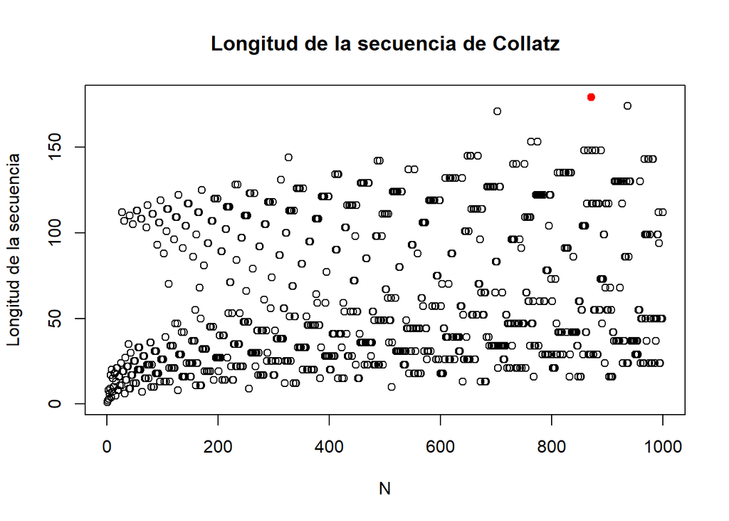

```r
plot(LonSec,
     main='Longitud de la secuencia de Collatz',
     xlab='N', ylab='Longitud de la secuencia')
points(idxMax, maxLon, pch=21, col='red', bg='red')
```